# Billboard Hot 100 & Spotify Audio Analysis

Author

Simona Cholakova

Published

June 5, 2026

## Introduction

Music is a reflection of its time. What makes certain song a “hit” has changed drastically over the years, not just in genre, but in its actual sound and structure. What makes analyzing music trends so fascinating is that it can reveal how our tastes and culture have evolved.

This project analyzes the Billboard Hot 100 chart data and Spotify audio features to uncover trends in popular music over time. The Billboard dataset covers chart data from the 1950s through 2021, providing over seven decades of popular music history. The analysis includes examining how the average sound of popular songs has evolved across decades, identifying top artists based on their chart performance and exploring wheater songs that reached #1 have distinct audio characteristics compared to those songs that did not. Additionally, songs are classified into mood categories based on their audio features, and the impact of artist collaborations on chart performance is investigated.

## Data

### Loading and inspecting data

```r
billboard <- read_csv("billboard/charts.csv")
spotify <- read_csv("spotify/dataset.csv")
```

```r
head(billboard) |> knitr::kable()
```

| date | rank | song | artist | last-week | peak-rank | weeks-on-board |
| --- | --- | --- | --- | --- | --- | --- |
| 2021-11-06 | 1 | Easy On Me | Adele | 1 | 1 | 3 |
| 2021-11-06 | 2 | Stay | The Kid LAROI & Justin Bieber | 2 | 1 | 16 |
| 2021-11-06 | 3 | Industry Baby | Lil Nas X & Jack Harlow | 3 | 1 | 14 |
| 2021-11-06 | 4 | Fancy Like | Walker Hayes | 4 | 3 | 19 |
| 2021-11-06 | 5 | Bad Habits | Ed Sheeran | 5 | 2 | 18 |
| 2021-11-06 | 6 | Way 2 Sexy | Drake Featuring Future & Young Thug | 6 | 1 | 8 |

```r
tibble(
  Column = c("date", "rank", "song", "artist", "last-week", "peak-rank", "weeks-on-board"),
  Type = c("date", "integer", "character", "character", "integer", "integer", "integer"),
  Description = c(
    "Date of the chart entry",
    "Chart position that week (1 = highest, 100 = lowest)",
    "Title of the song",
    "Name of the artist(s)",
    "Chart rank from the previous week",
    "Highest rank the song has ever reached",
    "Number of weeks the song has appeared on the Hot 100"
  )
) |> knitr::kable()
```

| Column | Type | Description |
| --- | --- | --- |
| date | date | Date of the chart entry |
| rank | integer | Chart position that week (1 = highest, 100 = lowest) |
| song | character | Title of the song |
| artist | character | Name of the artist(s) |
| last-week | integer | Chart rank from the previous week |
| peak-rank | integer | Highest rank the song has ever reached |
| weeks-on-board | integer | Number of weeks the song has appeared on the Hot 100 |

```r
head(spotify) |> knitr::kable()
```

| …1 | track_id | artists | album_name | track_name | popularity | duration_ms | explicit | danceability | energy | key | loudness | mode | speechiness | acousticness | instrumentalness | liveness | valence | tempo | time_signature | track_genre |
| --- | --- | --- | --- | --- | --- | --- | --- | --- | --- | --- | --- | --- | --- | --- | --- | --- | --- | --- | --- | --- |
| 0 | 5SuOikwiRyPMVoIQDJUgSV | Gen Hoshino | Comedy | Comedy | 73 | 230666 | FALSE | 0.676 | 0.4610 | 1 | -6.746 | 0 | 0.1430 | 0.0322 | 1.00e-06 | 0.3580 | 0.715 | 87.917 | 4 | acoustic |
| 1 | 4qPNDBW1i3p13qLCt0Ki3A | Ben Woodward | Ghost (Acoustic) | Ghost - Acoustic | 55 | 149610 | FALSE | 0.420 | 0.1660 | 1 | -17.235 | 1 | 0.0763 | 0.9240 | 5.60e-06 | 0.1010 | 0.267 | 77.489 | 4 | acoustic |
| 2 | 1iJBSr7s7jYXzM8EGcbK5b | Ingrid Michaelson;ZAYN | To Begin Again | To Begin Again | 57 | 210826 | FALSE | 0.438 | 0.3590 | 0 | -9.734 | 1 | 0.0557 | 0.2100 | 0.00e+00 | 0.1170 | 0.120 | 76.332 | 4 | acoustic |
| 3 | 6lfxq3CG4xtTiEg7opyCyx | Kina Grannis | Crazy Rich Asians (Original Motion Picture Soundtrack) | Can’t Help Falling In Love | 71 | 201933 | FALSE | 0.266 | 0.0596 | 0 | -18.515 | 1 | 0.0363 | 0.9050 | 7.07e-05 | 0.1320 | 0.143 | 181.740 | 3 | acoustic |
| 4 | 5vjLSffimiIP26QG5WcN2K | Chord Overstreet | Hold On | Hold On | 82 | 198853 | FALSE | 0.618 | 0.4430 | 2 | -9.681 | 1 | 0.0526 | 0.4690 | 0.00e+00 | 0.0829 | 0.167 | 119.949 | 4 | acoustic |
| 5 | 01MVOl9KtVTNfFiBU9I7dc | Tyrone Wells | Days I Will Remember | Days I Will Remember | 58 | 214240 | FALSE | 0.688 | 0.4810 | 6 | -8.807 | 1 | 0.1050 | 0.2890 | 0.00e+00 | 0.1890 | 0.666 | 98.017 | 4 | acoustic |

```r
tibble(
  Column = c("track_id", "artists", "album_name", "track_name", "popularity",
             "duration_ms", "explicit", "danceability", "energy", "key",
             "loudness", "mode", "speechiness", "acousticness",
             "instrumentalness", "liveness", "valence", "tempo",
             "time_signature", "track_genre"),
  Type = c("character", "character", "character", "character", "integer",
           "integer", "logical", "double", "double", "integer",
           "double", "integer", "double", "double",
           "double", "double", "double", "double",
           "integer", "character"),
  Unit = c("—", "—", "—", "—", "0–100",
           "milliseconds", "TRUE/FALSE", "0.0–1.0", "0.0–1.0", "0–11",
           "dB (–60 to 0)", "0 = minor, 1 = major", "0.0–1.0", "0.0–1.0",
           "0.0–1.0", "0.0–1.0", "0.0–1.0", "BPM",
           "beats per bar", "—"),
  Description = c(
    "Unique Spotify identifier for the track",
    "Name of the artist(s)",
    "Name of the album",
    "Title of the song",
    "Spotify popularity score (higher means more popular)",
    "Length of the song",
    "Whether the song contains explicit content",
    "How suitable the track is for dancing",
    "Perceptual measure of intensity and activity",
    "Musical key (0 = C, 1 = C#, ... 11 = B)",
    "Overall loudness of the track",
    "Modality of the track",
    "Presence of spoken words (>0.66 = speech, <0.33 = music)",
    "Confidence that the track is acoustic",
    "Predicts whether a track has no vocals",
    "Detects presence of a live audience",
    "Musical positiveness (higher = happier/more cheerful)",
    "Estimated speed of the track",
    "Estimated number of beats per bar",
    "Genre label assigned to the track"
  )
) |> knitr::kable()
```

| Column | Type | Unit | Description |
| --- | --- | --- | --- |
| track_id | character | — | Unique Spotify identifier for the track |
| artists | character | — | Name of the artist(s) |
| album_name | character | — | Name of the album |
| track_name | character | — | Title of the song |
| popularity | integer | 0–100 | Spotify popularity score (higher means more popular) |
| duration_ms | integer | milliseconds | Length of the song |
| explicit | logical | TRUE/FALSE | Whether the song contains explicit content |
| danceability | double | 0.0–1.0 | How suitable the track is for dancing |
| energy | double | 0.0–1.0 | Perceptual measure of intensity and activity |
| key | integer | 0–11 | Musical key (0 = C, 1 = C#, … 11 = B) |
| loudness | double | dB (–60 to 0) | Overall loudness of the track |
| mode | integer | 0 = minor, 1 = major | Modality of the track |
| speechiness | double | 0.0–1.0 | Presence of spoken words (>0.66 = speech, <0.33 = music) |
| acousticness | double | 0.0–1.0 | Confidence that the track is acoustic |
| instrumentalness | double | 0.0–1.0 | Predicts whether a track has no vocals |
| liveness | double | 0.0–1.0 | Detects presence of a live audience |
| valence | double | 0.0–1.0 | Musical positiveness (higher = happier/more cheerful) |
| tempo | double | BPM | Estimated speed of the track |
| time_signature | integer | beats per bar | Estimated number of beats per bar |
| track_genre | character | — | Genre label assigned to the track |

### Cleaning the data

```r
billboard_clean <- billboard |>
    mutate(
        song_clean = str_to_lower(str_trim(song)),
        artist_clean = str_to_lower(str_trim(artist))
    )

spotify_clean <- spotify |>
    mutate(
        song_clean = str_to_lower(str_trim(track_name)),
        artist_clean = str_to_lower(str_trim(artists))
    )
```

### Joining the tables

```r
combined_data <- billboard_clean |>
    inner_join(spotify_clean, by = c("song_clean", "artist_clean"), relationship = "many-to-many") |>
    distinct(song_clean, artist_clean, .keep_all = TRUE)
```

## Transformation & Analysis

### Average Sound by Decade

For each decade, what did the average popular song sound like?

```r
getDecade <- function(x){
  year = year(as.Date(x))
  decade = floor((year/10)) * 10
  decade
}
```

```r
decade_summary <- combined_data |>
  mutate(decade = getDecade(date)) |>
  summarise(
    across(c(danceability, energy, valence, tempo, loudness, acousticness),
           ~ mean(.x, na.rm = TRUE),
           .names = "avg_{.col}"),
    .by = decade
  ) |>
  arrange(decade)

decade_summary |> knitr::kable(digits = 3)
```

| decade | avg_danceability | avg_energy | avg_valence | avg_tempo | avg_loudness | avg_acousticness |
| --- | --- | --- | --- | --- | --- | --- |
| 1950 | 0.552 | 0.495 | 0.670 | 120.370 | -9.179 | 0.673 |
| 1960 | 0.527 | 0.536 | 0.653 | 117.961 | -9.707 | 0.484 |
| 1970 | 0.568 | 0.594 | 0.653 | 118.926 | -9.823 | 0.333 |
| 1980 | 0.594 | 0.685 | 0.635 | 121.924 | -9.058 | 0.195 |
| 1990 | 0.579 | 0.694 | 0.516 | 120.769 | -7.802 | 0.130 |
| 2000 | 0.545 | 0.767 | 0.494 | 127.339 | -5.305 | 0.103 |
| 2010 | 0.604 | 0.676 | 0.475 | 124.131 | -5.940 | 0.208 |
| 2020 | 0.650 | 0.614 | 0.511 | 118.247 | -6.459 | 0.276 |

### Interpretation of the results

Overall, popular music has grown louder, more energetic and darker in mood since the 1950s, with the 2000s marking a peak in production intensity before a slight return toward more acoustic and emotionally varied sounds in recent years.

### Top 20 Artists

Which 20 artists were the most successful on the Billboard Hot 100 in terms of total weeks spent on the chart, and how do their audio features compare?

```r
top20 <- combined_data |>
  summarise(
    total_weeks = sum(`weeks-on-board`, na.rm = TRUE),
    times_charted = n(),
    best_rank = min(`peak-rank`, na.rm = TRUE),
    .by = artist
  ) |>
  arrange(desc(total_weeks)) |>
  slice_head(n = 20)

top20 |> knitr::kable()
```

| artist | total_weeks | times_charted | best_rank |
| --- | --- | --- | --- |
| Nickelback | 409 | 18 | 1 |
| Imagine Dragons | 397 | 10 | 3 |
| Linkin Park | 335 | 19 | 2 |
| Adele | 304 | 14 | 1 |
| OneRepublic | 276 | 11 | 2 |
| Billy Joel | 273 | 16 | 1 |
| Bon Jovi | 251 | 13 | 1 |
| 3 Doors Down | 237 | 9 | 3 |
| Ariana Grande | 230 | 9 | 1 |
| Daughtry | 222 | 10 | 4 |
| Fall Out Boy | 217 | 11 | 2 |
| Billie Eilish | 216 | 17 | 1 |
| Dua Lipa | 213 | 6 | 2 |
| Aerosmith | 213 | 11 | 3 |
| Shawn Mendes | 203 | 6 | 2 |
| Travis Scott | 199 | 13 | 1 |
| Lady Gaga | 198 | 9 | 1 |
| The Fray | 196 | 7 | 3 |
| Red Hot Chili Peppers | 193 | 10 | 2 |
| Creed | 191 | 7 | 1 |

### Interpretation of the results

Nickelback leads with 409 total weeks on the chart across 18 songs, followed closely by Imagine Dragons (397 weeks) and Linkin Park (335 weeks), suggesting that rock and alternative artists tend to have longer-lasting chart success than pop artists. Adele stands out as the highest charting pop artist with 304 weeks and a best rank of #1, while Ariana Grande and Billie Eilish represent the newer generation of artists in the top 20. Notably, having more songs on the chart does not always correlate with a higher peak rank, for example Daughtry charted 10 songs but never surpassed rank #4, while Dua Lipa charted only 6 songs yet reached #2. Overall, the list skews heavily toward rock and alternative artists, which may reflect the time period covered by the Billboard dataset rather than current trends.

## Diferrences between #1 hits and other songs

Do songs that reach #1 sound different from songs that don’t?

```r
number_one_comparison <- combined_data |>
    mutate(was_number_one = if_else(`peak-rank` == 1, "Yes", "No")) |>
    summarise(
        avg_energy = mean(energy, na.rm = TRUE),
        avg_danceability = mean(danceability, na.rm = TRUE),
        avg_valence = mean(valence, na.rm = TRUE),
        avg_tempo = mean(tempo, na.rm = TRUE),
        avg_loudness = mean(loudness, na.rm = TRUE),
        song_count = n(),
        .by = was_number_one
    )

number_one_comparison |> knitr::kable(digits = 3)
```

| was_number_one | avg_energy | avg_danceability | avg_valence | avg_tempo | avg_loudness | song_count |
| --- | --- | --- | --- | --- | --- | --- |
| Yes | 0.593 | 0.598 | 0.580 | 117.333 | -8.474 | 241 |
| No | 0.675 | 0.578 | 0.546 | 122.928 | -7.264 | 1773 |

### Interpretation of the results

Surprisingly, songs that reached #1 are actually slightly less energetic (0.593 vs 0.675) and quieter (-8.474 vs -7.264) than songs that did not, which goes against the common assumption that #1 hits are the most intense or polished tracks. However, #1 songs score higher on both danceability (0.598 vs 0.578) and valence (0.580 vs 0.546), suggesting they tend to be more positive and danceable rather than simply louder or more energetic. The tempo of #1 hits is also slightly lower on average (117 vs 123 BPM). Overall, the differences are relatively small, indicating that audio features alone are not a strong predictor of whether a song will reach #1.

## Most consistent artists (charted in multiple decades)

Which artists have shown the most consistency by charting across multiple decades, and how do their audio features compare?

```r
consistent_artists <- combined_data |>
  mutate(decade = getDecade(date)) |>
  summarise(
    num_decades_appeared = n_distinct(decade),
    avg_danceability = mean(danceability, na.rm = TRUE),
    total_weeks = sum(`weeks-on-board`, na.rm = TRUE),
    best_rank = min(`peak-rank`, na.rm = TRUE),
    songs_on_chart = n_distinct(song_clean),
    .by = artist_clean
  ) |>
  filter(num_decades_appeared > 1) |>
  arrange(desc(num_decades_appeared), desc(total_weeks)) |>
  slice_head(n = 20) |>
  left_join(
    combined_data |> distinct(artist_clean, artist),
    by = "artist_clean"
  ) |>
  select(artist, everything(), -artist_clean)

consistent_artists |> knitr::kable(digits = 2)
```

| artist | num_decades_appeared | avg_danceability | total_weeks | best_rank | songs_on_chart |
| --- | --- | --- | --- | --- | --- |
| Bon Jovi | 4 | 0.44 | 251 | 1 | 13 |
| Bee Gees | 4 | 0.50 | 173 | 1 | 10 |
| Elvis Presley | 4 | 0.51 | 105 | 1 | 11 |
| Adele | 3 | 0.55 | 304 | 1 | 14 |
| Billy Joel | 3 | 0.58 | 273 | 1 | 16 |
| Aerosmith | 3 | 0.41 | 213 | 3 | 11 |
| Lady Gaga | 3 | 0.69 | 198 | 1 | 9 |
| Red Hot Chili Peppers | 3 | 0.59 | 193 | 2 | 10 |
| Creed | 3 | 0.43 | 191 | 1 | 7 |
| Elton John | 3 | 0.57 | 177 | 1 | 11 |
| Taylor Swift | 3 | 0.55 | 170 | 1 | 7 |
| Sade | 3 | 0.72 | 117 | 5 | 7 |
| Weezer | 3 | 0.55 | 106 | 10 | 5 |
| Metallica | 3 | 0.52 | 100 | 16 | 8 |
| Blondie | 3 | 0.60 | 95 | 1 | 6 |
| Michael Jackson | 3 | 0.62 | 94 | 1 | 5 |
| The Beach Boys | 3 | 0.51 | 91 | 1 | 9 |
| Carrie Underwood | 3 | 0.55 | 81 | 8 | 3 |
| Pearl Jam | 3 | 0.48 | 80 | 2 | 6 |
| Heart | 3 | 0.51 | 80 | 1 | 4 |

## Song Mood Classification

How can we classify the mood of songs based on their audio features?

```r
combined_data <- combined_data |>
    mutate(mood = case_when(
        valence >= 0.6 & energy >= 0.6 ~ "Happy and Energetic",
        valence >= 0.6 & energy < 0.6  ~ "Happy but Calm",
        valence < 0.6  & energy >= 0.6 ~ "Dark and Energetic",
        TRUE                            ~ "Dark and Calm"
    ))

combined_data |>
  select(song, artist, valence, energy, mood) |>
  head(50) |>
  knitr::kable(digits = 3)
```

| song | artist | valence | energy | mood |
| --- | --- | --- | --- | --- |
| Easy On Me | Adele | 0.130 | 0.366 | Dark and Calm |
| Fancy Like | Walker Hayes | 0.855 | 0.765 | Happy and Energetic |
| Bad Habits | Ed Sheeran | 0.537 | 0.893 | Dark and Energetic |
| Shivers | Ed Sheeran | 0.822 | 0.859 | Happy and Energetic |
| Good 4 U | Olivia Rodrigo | 0.688 | 0.664 | Happy and Energetic |
| Need To Know | Doja Cat | 0.194 | 0.609 | Dark and Energetic |
| Levitating | Dua Lipa | 0.914 | 0.884 | Happy and Energetic |
| Heat Waves | Glass Animals | 0.531 | 0.525 | Dark and Calm |
| Traitor | Olivia Rodrigo | 0.085 | 0.339 | Dark and Calm |
| Montero (Call Me By Your Name) | Lil Nas X | 0.710 | 0.503 | Happy but Calm |
| Thats What I Want | Lil Nas X | 0.546 | 0.846 | Dark and Energetic |
| Pepas | Farruko | 0.442 | 0.766 | Dark and Energetic |
| Happier Than Ever | Billie Eilish | 0.303 | 0.238 | Dark and Calm |
| Ghost | Justin Bieber | 0.441 | 0.741 | Dark and Energetic |
| A-O-K | Tai Verdes | 0.862 | 0.626 | Happy and Energetic |
| Knowing You | Kenny Chesney | 0.178 | 0.562 | Dark and Calm |
| Woman | Doja Cat | 0.881 | 0.764 | Happy and Energetic |
| ’Til You Can’t | Cody Johnson | 0.460 | 0.815 | Dark and Energetic |
| Whiskey And Rain | Michael Ray | 0.718 | 0.623 | Happy and Energetic |
| 2055 | Sleepy Hallow | 0.638 | 0.512 | Happy but Calm |
| Money | Lisa | 0.400 | 0.553 | Dark and Calm |
| To Be Loved By You | Parker McCollum | 0.488 | 0.805 | Dark and Energetic |
| Life Goes On | Oliver Tree | 0.569 | 0.490 | Dark and Calm |
| Deja Vu | Olivia Rodrigo | 0.178 | 0.612 | Dark and Energetic |
| Yonaguni | Bad Bunny | 0.440 | 0.648 | Dark and Energetic |
| Todo de Ti | Rauw Alejandro | 0.342 | 0.718 | Dark and Energetic |
| Butter | BTS | 0.695 | 0.459 | Happy but Calm |
| The Feels | TWICE | 0.922 | 0.903 | Happy and Energetic |
| Arcade | Duncan Laurence | 0.266 | 0.329 | Dark and Calm |
| Country Again | Thomas Rhett | 0.248 | 0.481 | Dark and Calm |
| Lalisa | Lisa | 0.854 | 0.652 | Happy and Energetic |
| Single Saturday Night | Cole Swindell | 0.653 | 0.786 | Happy and Energetic |
| Heartbreak Anniversary | Giveon | 0.543 | 0.465 | Dark and Calm |
| Forever After All | Luke Combs | 0.456 | 0.650 | Dark and Energetic |
| I Am Not A Woman, I’m A God | Halsey | 0.518 | 0.700 | Dark and Energetic |
| Blinding Lights | The Weeknd | 0.334 | 0.730 | Dark and Energetic |
| Glad You Exist | Dan + Shay | 0.692 | 0.499 | Happy but Calm |
| Without You | The Kid LAROI | 0.467 | 0.413 | Dark and Calm |
| Astronaut In The Ocean | Masked Wolf | 0.472 | 0.695 | Dark and Energetic |
| Visiting Hours | Ed Sheeran | 0.263 | 0.396 | Dark and Calm |
| I Guess I’m In Love | Clinton Kane | 0.223 | 0.340 | Dark and Calm |
| Permission To Dance | BTS | 0.646 | 0.741 | Happy and Energetic |
| Ball If I Want To | DaBaby | 0.628 | 0.669 | Happy and Energetic |
| Steal My Love | Dan + Shay | 0.751 | 0.633 | Happy and Energetic |
| NDA | Billie Eilish | 0.554 | 0.373 | Dark and Calm |
| Happier | Olivia Rodrigo | 0.338 | 0.443 | Dark and Calm |
| Rare | Nas | 0.518 | 0.851 | Dark and Energetic |
| Billie Bossa Nova | Billie Eilish | 0.549 | 0.389 | Dark and Calm |
| Oxytocin | Billie Eilish | 0.180 | 0.598 | Dark and Calm |
| I Didn’t Change My Number | Billie Eilish | 0.677 | 0.480 | Happy but Calm |

### Interpretation of the results

The mood classification reveals a clear dominance of darker toned songs in this sample, with “Dark and Energetic” and “Dark and Calm” appearing most frequently. Well known upbeat hits like Levitating by Dua Lipa and The Feels by TWICE are correctly classified as “Happy and Energetic”, while emotionally heavy songs like Traitor and Happier by Olivia Rodrigo fall into “Dark and Calm” as expected, suggesting the classification is working as intended. Billie Eilish stands out with multiple songs in the dark categories, consistent with her signature moody sound. Interestingly, some songs that feel upbeat on the surface, such as Blinding Lights by The Weeknd, are classified as “Dark and Energetic” due to high energy but low valence, showing that the audio features capture emotional nuance beyond what song titles or artist reputation might suggest.

## Solo vs. Collaboration Trends

What are the differences in chart performance between solo artists and collaborations?

```r
combined_data <- combined_data |>
  mutate(artist_type = case_when(
    str_detect(artist, regex("&|\\+|\\bx\\b", ignore_case = TRUE)) ~ "Collab",
    TRUE ~ "Solo"
  ))

combined_data |>
  summarise(
    song_count = n(),
    avg_weeks = mean(`weeks-on-board`, na.rm = TRUE),
    avg_peak_rank = mean(`peak-rank`, na.rm = TRUE),
    .by = artist_type
  ) |>
  knitr::kable(digits = 2)
```

| artist_type | song_count | avg_weeks | avg_peak_rank |
| --- | --- | --- | --- |
| Solo | 1961 | 17.67 | 30.51 |
| Collab | 53 | 17.94 | 25.68 |

### Interpretation of the results

Collaborative acts slightly outperform solo artists in both average weeks on chart (17.94 vs 17.67) and average peak rank (25.68 vs 30.51, where a lower number means a higher chart position), suggesting that artist collaborations tend to reach higher chart positions and sustain chart presence marginally longer. However, with only 53 collaborative songs compared to 1961 solo entries, the sample size is too small to draw strong conclusions, so these differences should be interpreted with caution.

## Exploratory data analysis

### Plot 1: Audio Feature Trends by Decade

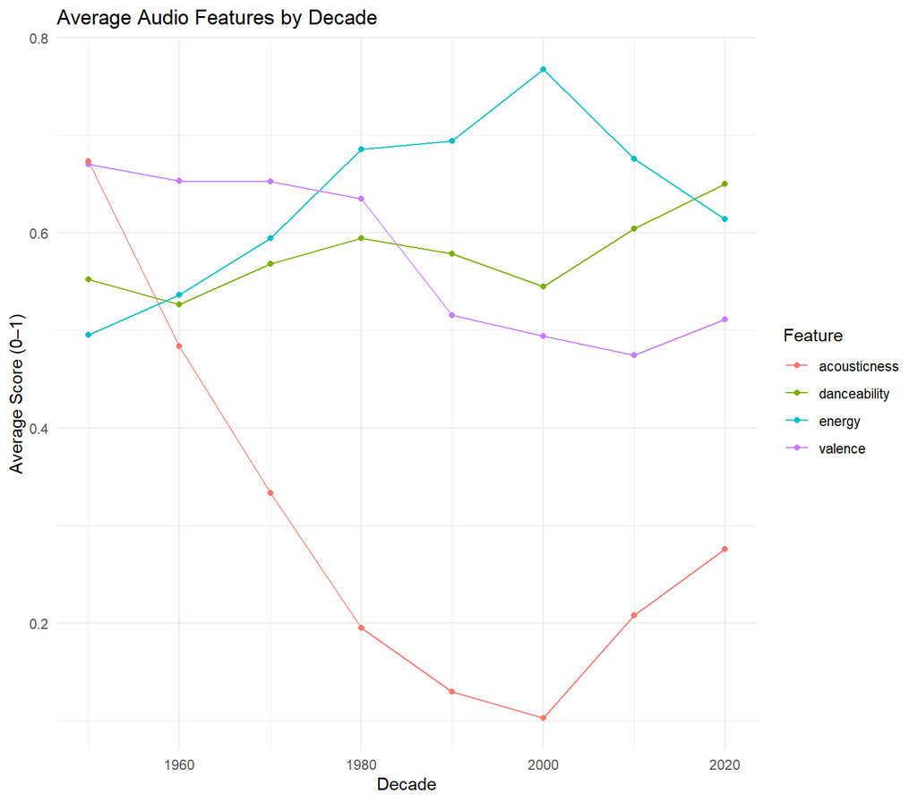

```r
decade_long <- decade_summary |>
  pivot_longer(
    cols = starts_with("avg_"),
    names_to = "feature",
    names_prefix = "avg_",
    values_to = "value"
  ) |>
  filter(feature %in% c("danceability", "energy", "valence", "acousticness"))

ggplot(decade_long, aes(x = decade, y = value, color = feature)) +
  geom_line() +
  geom_point() +
  labs(
    title = "Average Audio Features by Decade",
    x = "Decade",
    y = "Average Score (0–1)",
    color = "Feature"
  ) +
  theme_minimal()
```

### Plot 2: Top 20 Artists by Total Weeks on Chart

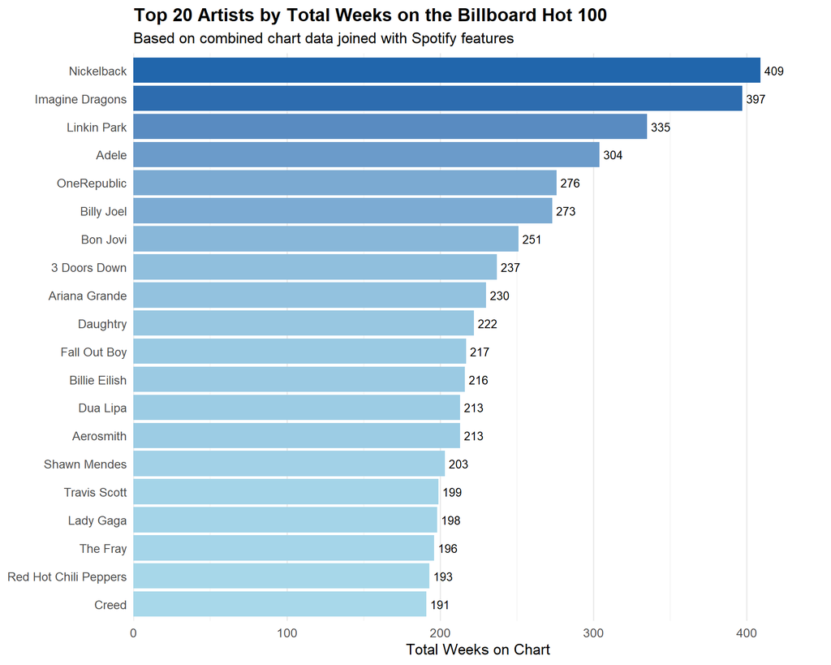

```r
top20_plot <- top20 |>
  mutate(artist = fct_reorder(artist, total_weeks))

ggplot(top20_plot, aes(x = total_weeks, y = artist, fill = total_weeks)) +
  geom_col(show.legend = FALSE) +
  geom_text(aes(label = total_weeks), hjust = -0.2, size = 3.5) +
  scale_fill_gradient(low = "#a8d8ea", high = "#2166ac") +
  scale_x_continuous(expand = expansion(mult = c(0, 0.1))) +
  labs(
    title = "Top 20 Artists by Total Weeks on the Billboard Hot 100",
    subtitle = "Based on combined chart data joined with Spotify features",
    x = "Total Weeks on Chart", y = NULL
  ) +
  theme_minimal(base_size = 13) +
  theme(plot.title = element_text(face = "bold"),
        panel.grid.major.y = element_blank())
```

#### Interpretation of the plot

A **horizontal bar chart** is used here because we are comparing a single numeric value (total weeks) across many categories (artists). The horizontal orientation makes the artist names readable without rotation, and ordering by value immediately shows the ranking. Nickelback leads with 409 total weeks, followed by Imagine Dragons (397) and Linkin Park (335). The dominance of rock and alternative artists at the top suggests these genres produce songs with longer-lasting chart presence compared to pop. Adele is the only pop artist in the top 5, standing out with 304 weeks.

### Plot 3: Mood Distribution of Billboard Songs

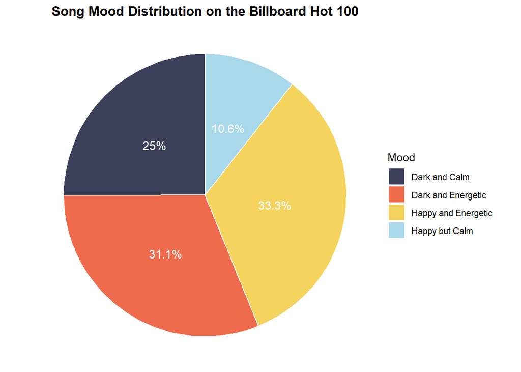

```r
mood_counts <- combined_data |>
  count(mood) |>
  mutate(
    pct   = n / sum(n),
    label = paste0(mood, "\n", round(pct * 100, 1), "%")
  )

ggplot(mood_counts, aes(x = "", y = n, fill = mood)) +
  geom_col(width = 1, color = "white") +
  coord_polar(theta = "y") +
  scale_fill_manual(values = c(
    "Happy and Energetic" = "#f4d35e",
    "Happy but Calm"      = "#a8d8ea",
    "Dark and Energetic"  = "#ee6c4d",
    "Dark and Calm"       = "#3d405b"
  )) +
  geom_text(aes(label = paste0(round(pct * 100, 1), "%")),
            position = position_stack(vjust = 0.5),
            color = "white", size = 4) +
  labs(title = "Song Mood Distribution on the Billboard Hot 100",
       fill = "Mood") +
  theme_void() +
  theme(plot.title = element_text(face = "bold", hjust = 0.5))
```

#### Interpretation of the plot

A **pie chart** is used here because we are showing how a whole (all songs) is divided into parts (mood categories). It is suitable when there are a small number of categories and the goal is to compare proportions. Happy and Energetic is the most common mood at 33.3%, closely followed by Dark and Energetic at 31.1%. Dark and Calm accounts for 25%, while Happy but Calm is the least common at only 10.6%. This shows that the majority of Billboard hits lean toward high energy, regardless of whether they are emotionally positive or dark.

### Plot 4: #1 Hits vs. Others — Audio Feature Comparison

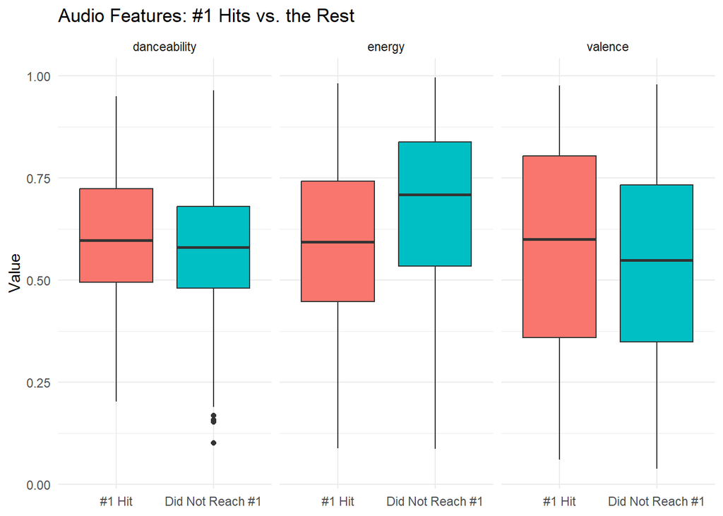

```r
feature_comparison <- combined_data |>
  mutate(was_number_one = if_else(`peak-rank` == 1, "#1 Hit", "Did Not Reach #1")) |>
  select(was_number_one, danceability, energy, valence) |>
  pivot_longer(cols = -was_number_one,
               names_to = "feature", values_to = "value")

ggplot(feature_comparison, aes(x = was_number_one, y = value, fill = was_number_one)) +
  geom_boxplot(show.legend = FALSE) +
  facet_wrap(~ feature) +
  labs(
    title = "Audio Features: #1 Hits vs. the Rest",
    x = NULL,
    y = "Value"
  ) +
  theme_minimal()
```

#### Interpretation of the plot

A **boxplot** is used here because we are comparing the distribution of continuous audio features (danceability, energy, valence) across two groups (#1 hits vs. the rest). Unlike a bar chart showing only means, a boxplot also shows the median, spread, and outliers, giving a bigger picture of how the groups differ. Across all three features the differences between #1 hits and non-#1 songs are small, confirming that audio features alone are not strong predictors of chart success. #1 hits show slightly higher valence and danceability medians, suggesting they tend to be more positive and danceable. Energy is slightly lower for #1 hits, which goes against the intuition that the most successful songs are the most intense.

### Plot 5: Most Consistent Artists by Total Weeks and Decades Appeared

[figure not shown]

```r
ggplot(consistent_artists |> slice_head(n = 20),
       aes(x = total_weeks, y = fct_reorder(artist, total_weeks),
           color = factor(num_decades_appeared))) +
  geom_point(size = 4) +
  labs(
    title = "Most Consistent Artists on the Billboard Hot 100",
    x = "Total Weeks on Chart",
    y = NULL,
    color = "Decades Appeared"
  ) +
  theme_minimal()
```

#### Interpretation of the plot

A **dot plot** is used here because we are comparing a continuous variable (total weeks on chart) across a ranked list of artists, while also encoding a second categorical variable (number of decades) through color. It is less cluttered than a bar chart for this type of comparison and makes individual values easy to read. Adele leads with the most total weeks (~304) despite appearing in only 3 decades, showing she accumulated chart time rapidly. Bon Jovi is the standout among 4-decade artists with ~251 weeks, while the Bee Gees and Elvis Presley also span 4 decades but have fewer weeks, likely because their peak activity predated the modern era of sustained chart tracking. Among the 3-decade artists, total weeks on chart varies widely, from around 80 weeks (Heart, Pearl Jam) to 304 weeks (Adele), showing that spanning multiple decades does not guarantee a high total chart presence.

## Conclusion

This project explored how popular music has changed over the decades using Billboard Hot 100 chart data and Spotify audio features. The analysis showed that popular songs have become louder, more energetic, and darker in mood since the 1950s. Surprisingly, #1 hits are not necessarily the most intense tracks, they tend to score higher in danceability and positivity rather than energy or loudness. Artists with the longest chart careers are mostly from rock and alternative genres, and a small number of legends like Bon Jovi and Elvis Presley managed to chart across four different decades. Overall, while audio features can reveal interesting patterns, they alone cannot fully predict a song’s success because chart performance is shaped by many factors beyond just how a song sounds.

## References

**Datasets:**

[Billboard Hot 100 Songs](https://www.kaggle.com/datasets/dhruvildave/billboard-the-hot-100-songs)

[Spotify Tracks Dataset](https://www.kaggle.com/datasets/maharshipandya/-spotify-tracks-dataset)

**Loudness War:**

[Ultimate Guide to the Loudness War](https://hyperbits.com/ultimate-guide-to-the-loudness-war/)